# Projet ADM Q2

RODRIGUES Camille-Astrid AMOUROUX Jan

2025-03-31

======================= QUESTION 2 =======================

–> espèces : caractéristiques

–> habitat : caractéristiques

```
==> impact de l'habitat sur les caractéristiques de l'espèce
```

–> petit ou grand selon la température, etc …

Ouverture des données :

```r
habitat = read.table("../data/habitat.tsv", sep = "\t",
                     stringsAsFactors = T, header = T, na.strings = T)
especes = read.table("../data/especes.tsv", sep = "\t",
                     stringsAsFactors = T, header = T, na.strings = T)
commu = read.table("../data/communautes.tsv", sep = "\t",
                   stringsAsFactors = T, header = T, na.strings = T)

habitat = habitat[,-2:-3]
name = colnames(habitat)
colnames(habitat) = name
```

ANALYSE :

#### ==> extraire informations précédentes = subset par colonnes dont on extrait les numéros des localisations

Création des subsets de numéro de lieu ayant des Gem (Colombe.a.croissants)

```r
# Récupération des noms des colonnes correspondant aux espèces (colonnes 2 à 17)
vectNom = names(commu[2:17])

# Création d'une liste vide pour stocker les sous-ensembles
listSubsets = list()
# Parcours de toutes les espèces
for (i in 1:length(vectNom)) {
  especesActu = vectNom[i]
  # Extraction des numéros de lieu (IdPE) où l'espèce a une présence (valeur 1)
  foosubset = commu$IdPE[commu[[especesActu]] == 1]
  listSubsets[[especesActu]] = foosubset
}

listSubsets$Gem
```

```
##   [1] 155 162 163 167 168 217 223 229 235 250 253 262 271 289 294 308 309 314
##  [19] 315 316 320 326 349 374 376 381 386 403 416 431 450 453 456 457 459 466
##  [37] 467 483 484 504 517 521 522 535 540 546 561 565 568 570 572 575 592 599
##  [55] 601 602 620 621 624 625 627 653 667 677 679 681 683 685 687 690 696 702
##  [73] 714 717 718 720 721 723 725 734 735 736 751 756 765 782 783 784 785 786
##  [91] 788 792 797 798 808 809 813 815 819 820 822 825 826 827 834 835 836 837
## [109] 841 844 845 846 849 851 852 853 855 866 870 875 877 880 882 887 891 893
## [127] 900 903 904 908 909
```

On a toutes les localisation de chaque espèce

Exemple d’appel pour les localisation de Gem : listSubsets$gem

#### ==> moyenne des données sur l’habitat pour chaque colonne du subset (espèces)

Pour se donner une idée de vers ou on vas, nous allons regarder chaque moyenne de variables

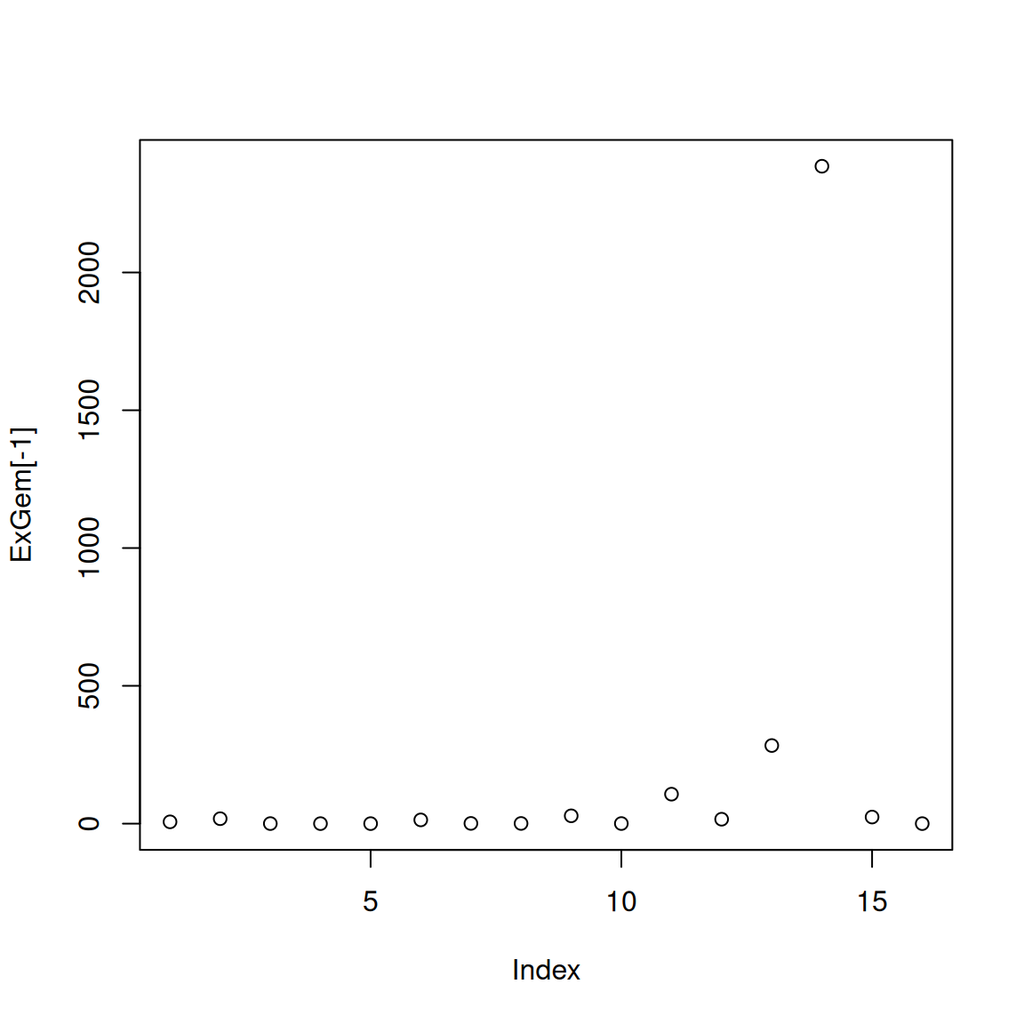

```r
par(mfrow = c(1,1))
ExGem = colMeans(subset(habitat, habitat$IdPE %in% listSubsets$Gem))
plot(ExGem[-1])
```

Nous voyons que les unitées sont biaisées, il est donc nécécaire de normaliser

Généraliser par une boucle tapply :

```r
ExMat = t(sapply(names(listSubsets), function(name) {
  colMeans(subset(habitat, habitat$IdPE %in% listSubsets[[name]]))
}))
ExMat = ExMat[,-1]
```

/!\ sapply == tapply mais pour sortir une matrice et pas une liste /!\

## ChiTest²

```r
chisq.test(habitat[,2:17])
```

```
##
##  Pearson's Chi-squared test
##
## data:  habitat[, 2:17]
## X-squared = 223601, df = 13695, p-value < 2.2e-16
```

```r
for (i in 2:17){
  print(chisq.test(habitat[,i]))
}
```

```
##
##  Chi-squared test for given probabilities
##
## data:  habitat[, i]
## X-squared = 3.1306, df = 913, p-value = 1
##
##
##  Chi-squared test for given probabilities
##
## data:  habitat[, i]
## X-squared = 0.89333, df = 913, p-value = 1
##
##
##  Chi-squared test for given probabilities
##
## data:  habitat[, i]
## X-squared = 233.85, df = 913, p-value = 1
##
##
##  Chi-squared test for given probabilities
##
## data:  habitat[, i]
## X-squared = 56.511, df = 913, p-value = 1
##
##
##  Chi-squared test for given probabilities
##
## data:  habitat[, i]
## X-squared = 270.42, df = 913, p-value = 1
##
##
##  Chi-squared test for given probabilities
##
## data:  habitat[, i]
## X-squared = 8438.3, df = 913, p-value < 2.2e-16
##
##
##  Chi-squared test for given probabilities
##
## data:  habitat[, i]
```

[output cut: 40 more lines]

```
##
## data:  habitat[, i]
## X-squared = 167676, df = 913, p-value < 2.2e-16
##
##
##  Chi-squared test for given probabilities
##
## data:  habitat[, i]
## X-squared = 70.922, df = 913, p-value = 1
##
##
##  Chi-squared test for given probabilities
##
## data:  habitat[, i]
## X-squared = 18.291, df = 913, p-value = 1
```

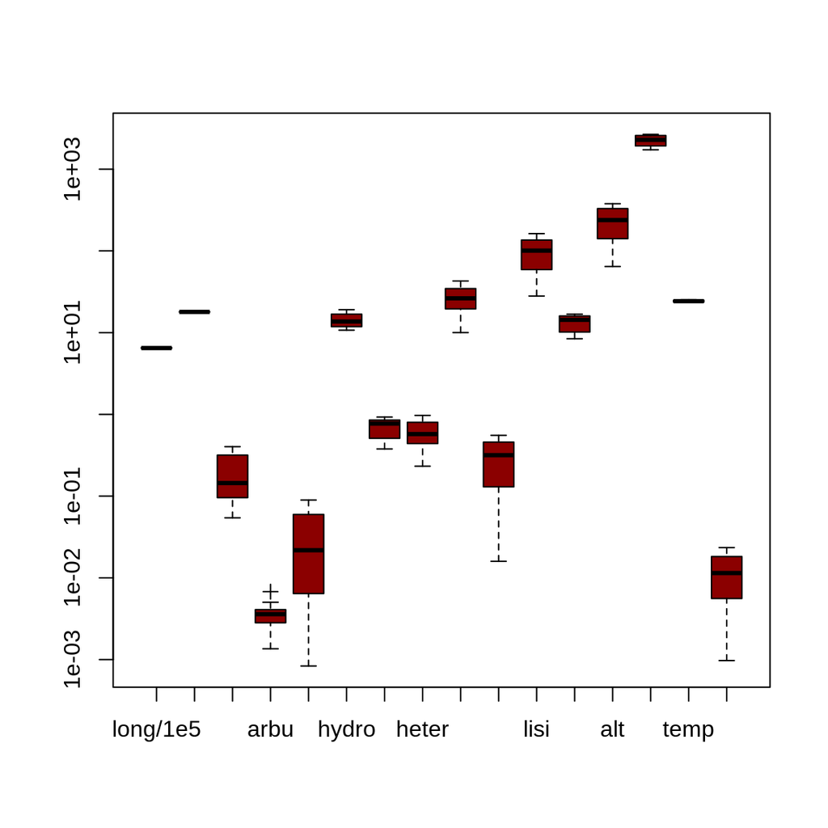

```r
boxplot(ExMat,
     pch = 3, col = "darkred",
     log = "y")
```

Boxplot avec une normalisation au log10()

```r
ExMat.meannorm = scale(ExMat, center = T, scale = T)
```

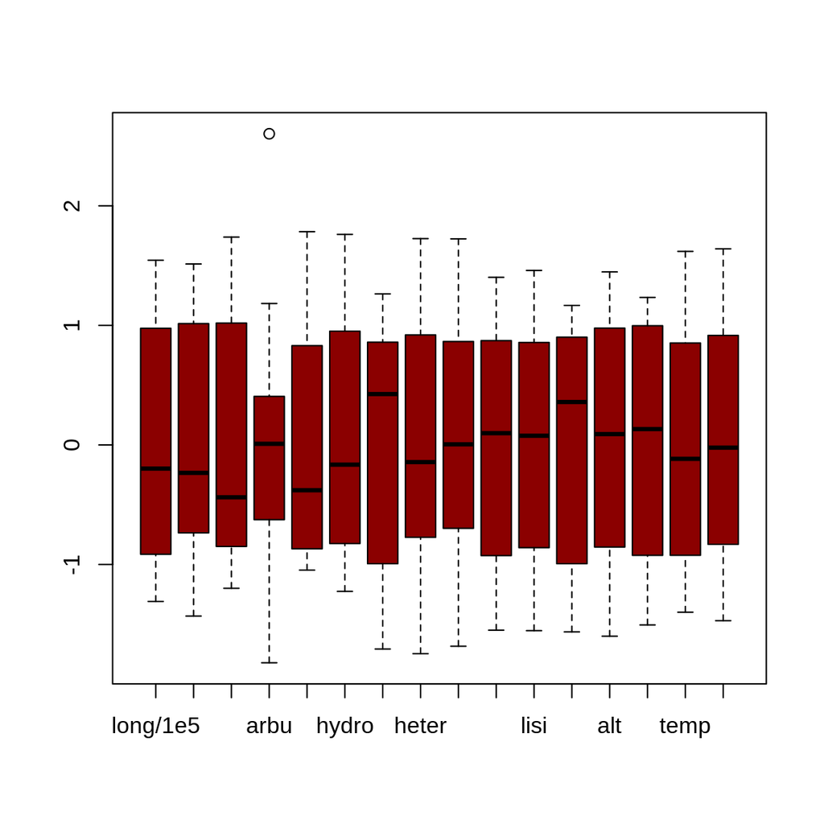

```r
boxplot.matrix(ExMat.meannorm, col = "darkred")
```

normalisation centré réduite à la moyenne

Des boxplots plus interresant (par classe):

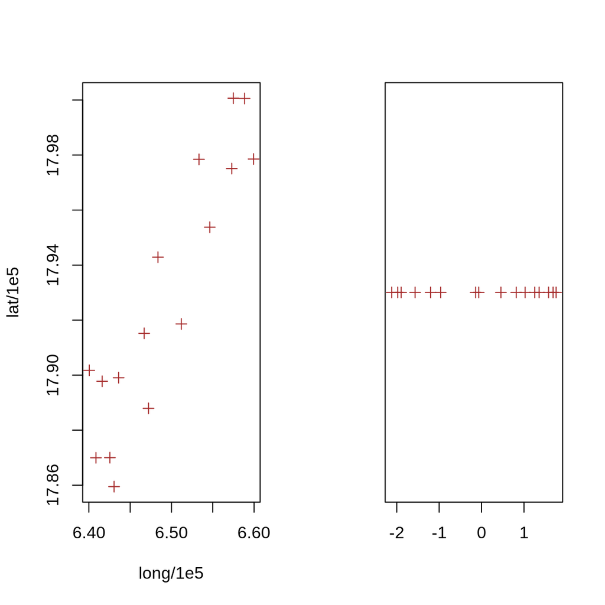

```r
par(mfrow = c(1,2))

#   1. Point d'écoute :

plot(ExMat[,1:2],
     pch = 3, col = "brown")

acp.Ecoute = dudi.pca(ExMat[,1:2], center = TRUE, scale = TRUE,
                 ,scannf = FALSE, nf = 1)
plot(acp.Ecoute$li,
     pch = 3, col = "brown")
```

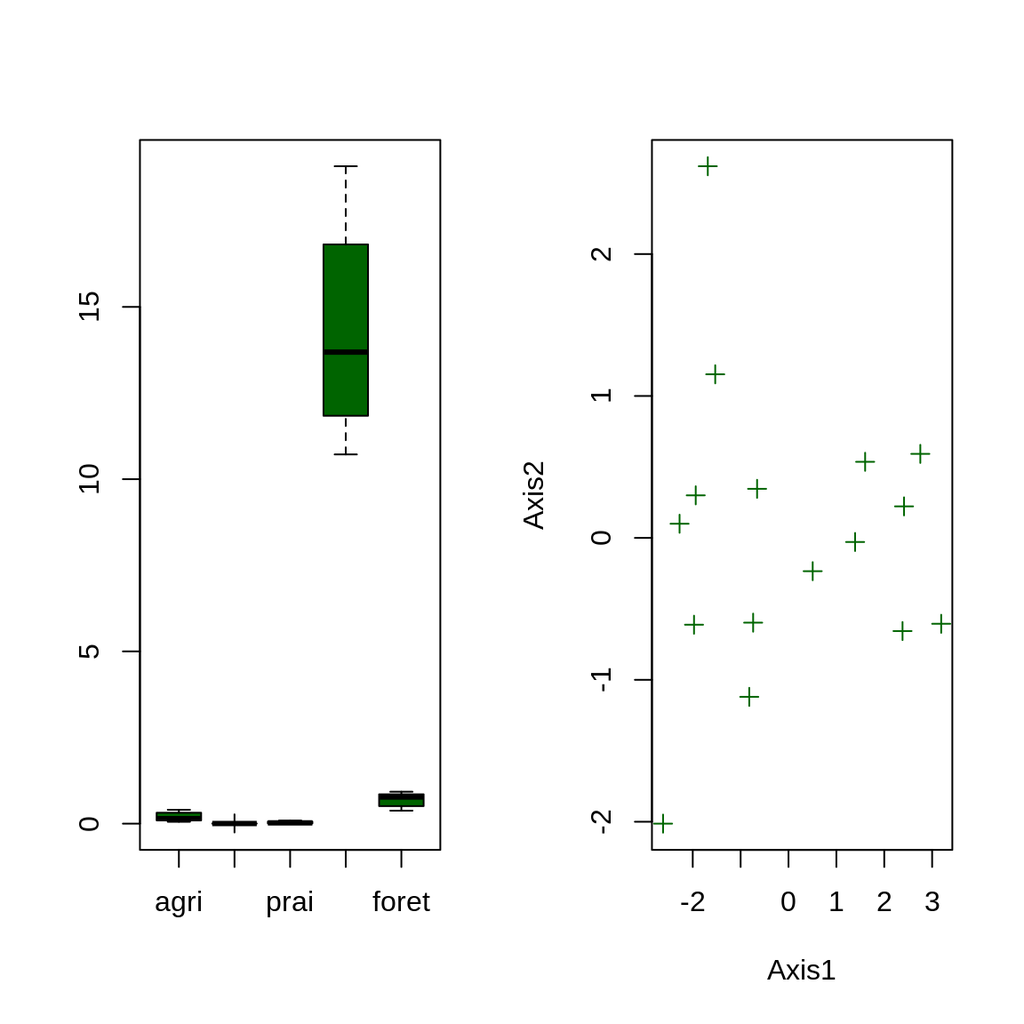

```r
#corrélation +

#  2. Occupation du sol :

boxplot(ExMat[,3:7],
     pch = 3, col = "darkgreen")

acp.Ocuu = dudi.pca(ExMat[,3:7], center = TRUE, scale = TRUE,
                 scannf = FALSE, nf = 2)
plot(acp.Ocuu$li,
     pch = 3, col = "darkgreen")
```

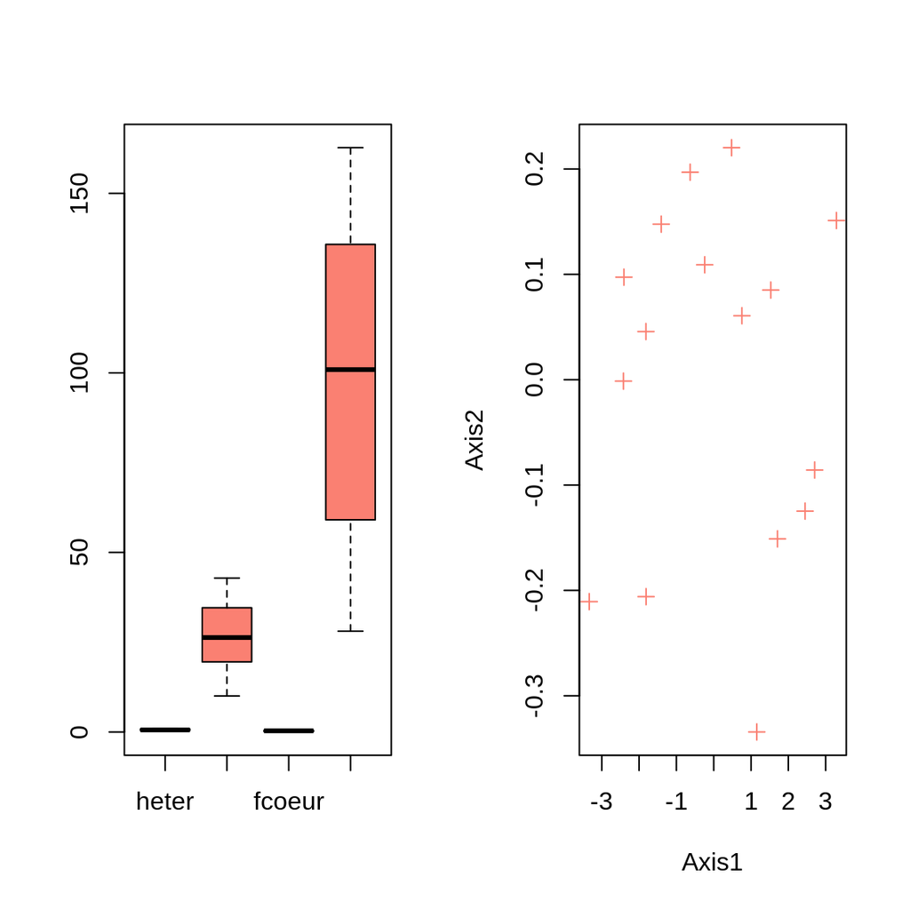

```r
# pas de corrélation

#  3. Fragmentation :

boxplot(ExMat[,8:11],
     pch = 3, col = "salmon")


acp.Frag = dudi.pca(ExMat[,8:11], center = TRUE, scale = TRUE,
                 scannf = FALSE, nf = 2)
plot(acp.Frag$li,
     pch = 3, col = "salmon")
```

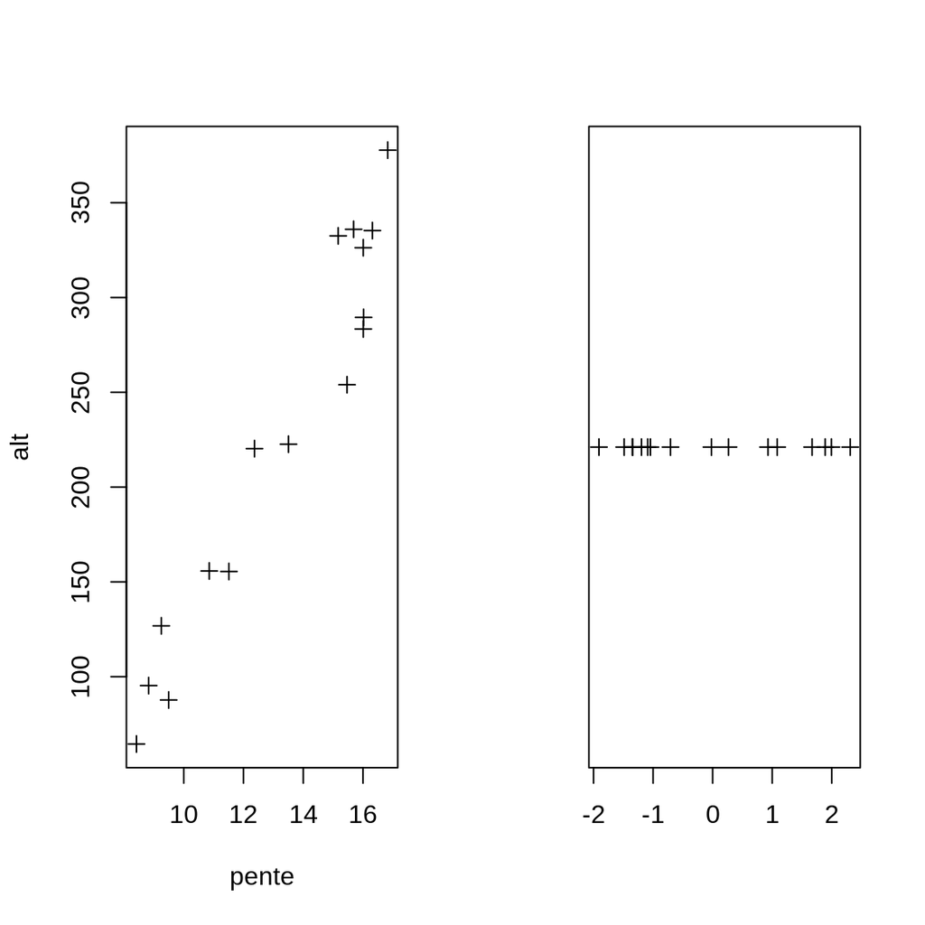

```r
# pas de corrélation

#  4. Topographie

plot(ExMat[,12:13],
     pch = 3, col = "black")

acp.Topo = dudi.pca(ExMat[,12:13], center = TRUE, scale = TRUE,
                 scannf = FALSE, nf = 1)
plot(acp.Topo$li,
     pch = 3, col = "black")
```

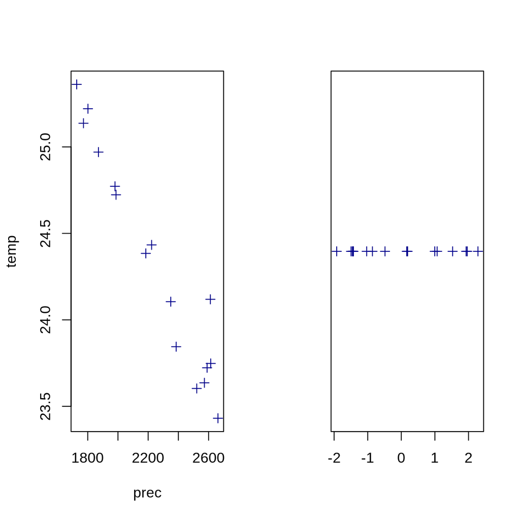

```r
# corrélation +

#  5. condition topographique

plot(ExMat[,14:15],
     pch = 3, col = "darkblue")

acp.CondTopo = dudi.pca(ExMat[,14:15], center = TRUE, scale = TRUE,
                 scannf = FALSE, nf = 1)
plot(acp.CondTopo$li,
     pch = 3, col = "darkblue")
```

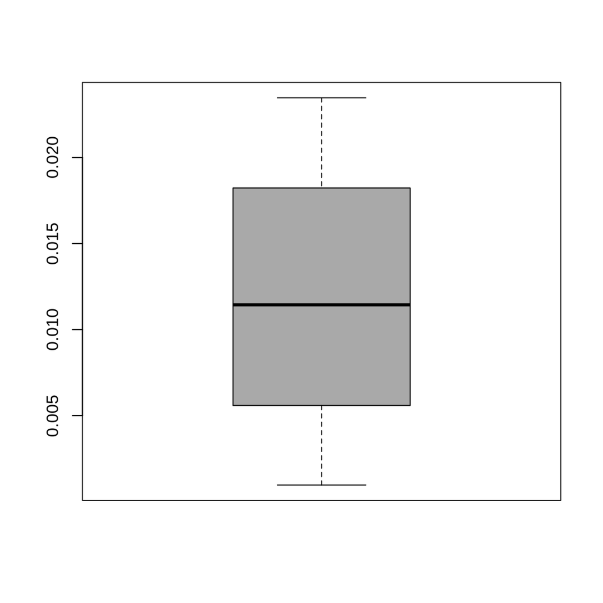

```r
# corrélation -

#  6. Urbanisation

par(mfrow = c(1,1))
boxplot(ExMat[,16],
     pch = 3, col = "darkgray")
```

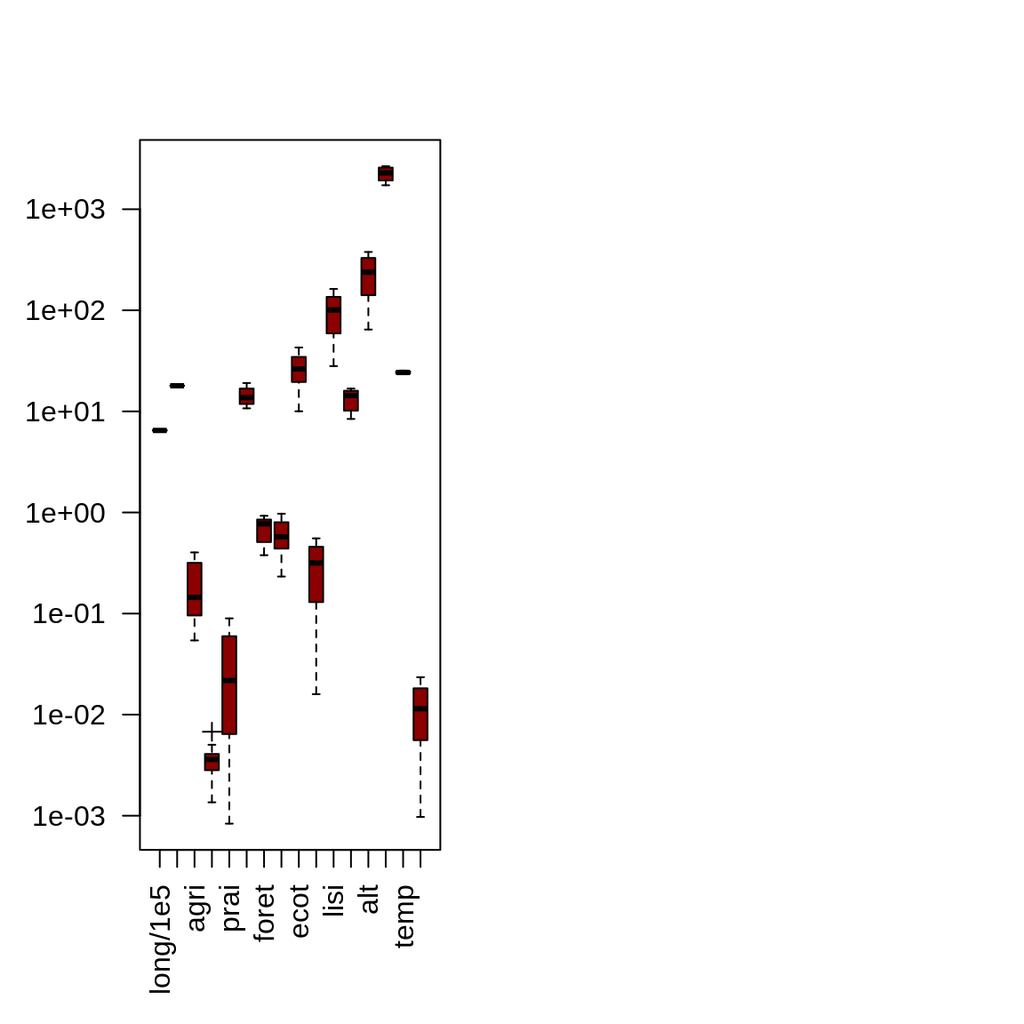

```r
# c'est une ligne

# 7. Total
par(mfrow = c(1,2))
boxplot(ExMat,
     pch = 3, col = "darkred",
     las = 2, log = "y")
acp.Total = dudi.pca(ExMat[,1:15], center = TRUE, scale = TRUE,
                     scannf = FALSE, nf = 2)

# bordel imonde
```

- Point d’écoute semble avoir une corrélation positive
- Occupation du sol ne semble pas être corrélé
- Fragmentation ne semble pas être corrélé
- Topographie semble être corrélé positivement
- condition topographique semble être corrélé négativement

#### ==> expliquer chacune des variables de l’espèce en fonction des variables de l’environnement

```
--> Ex :  taille petite quand température haute, alimentation quand hydrométrie élevée
```

Faire des AFD par catégorie pour voir si impact sur l’alimentation

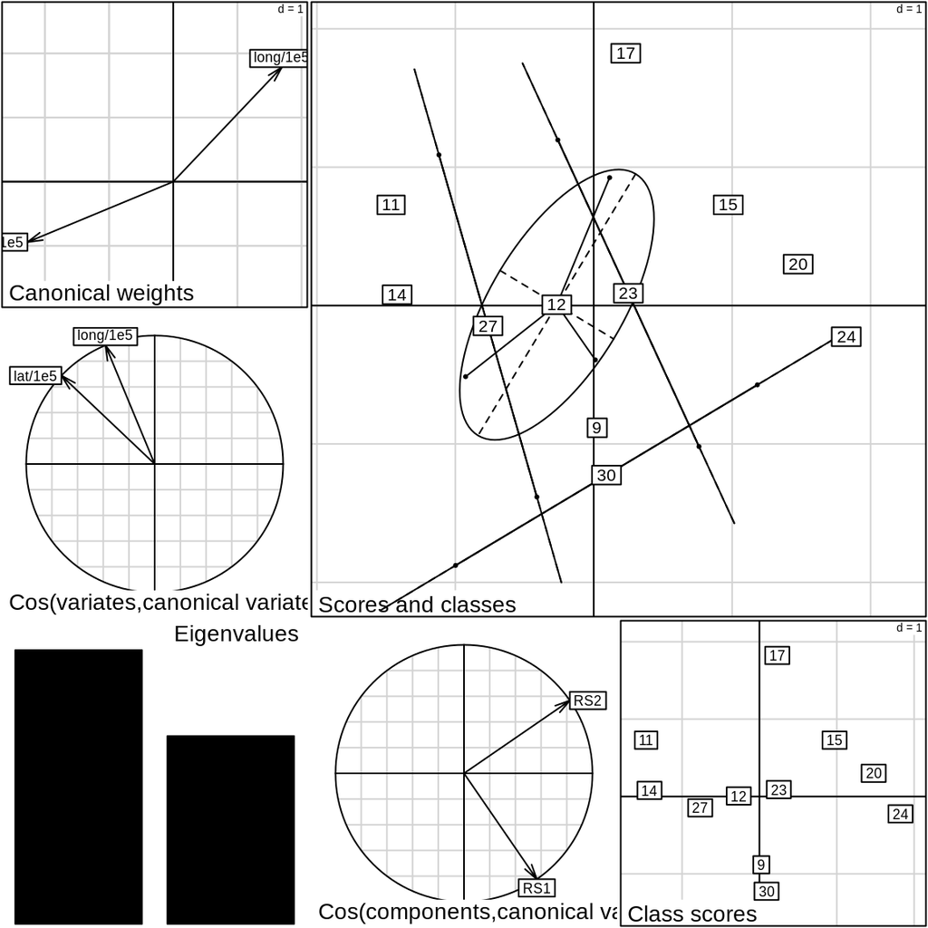

```r
# discrimin = AFD
# les arg : (acp, var qualitative)
afd.Ecoute.Taille = discrimin(acp.Ecoute,as.factor(especes$Taille)
                 , scannf = FALSE, nf = 2)

plot(afd.Ecoute.Taille)
```

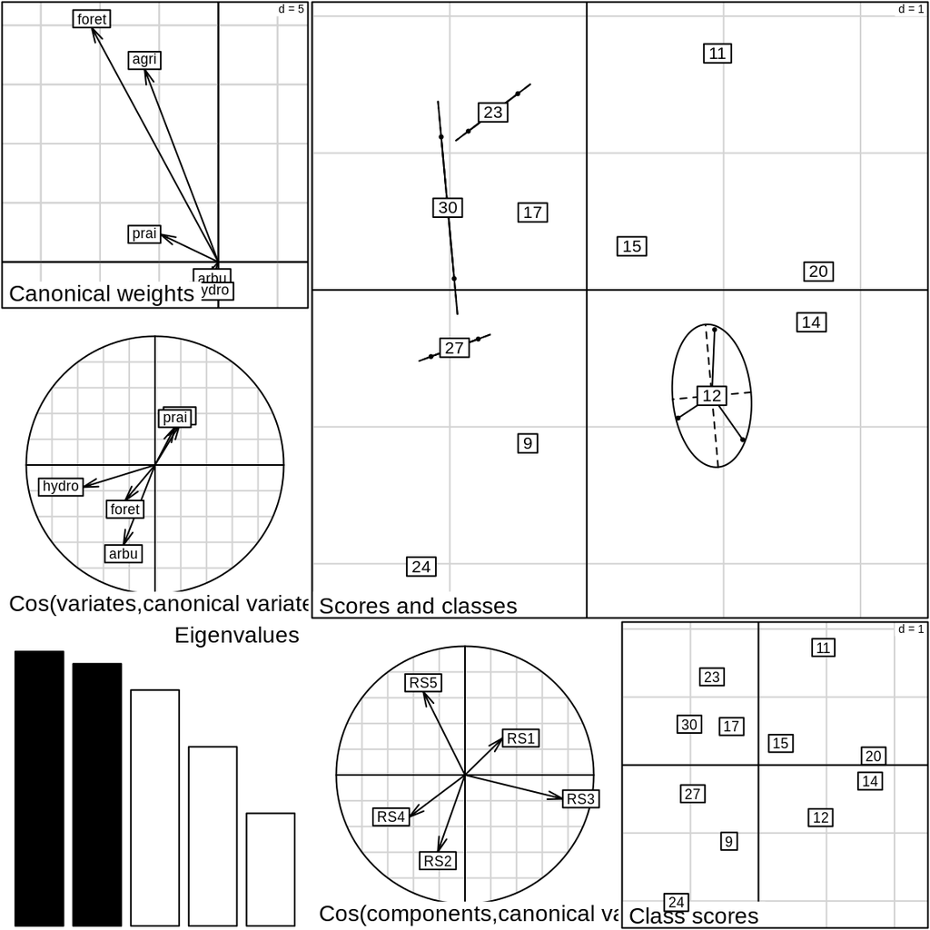

```r
#########
afd.Ocuu.Taille = discrimin(acp.Ocuu,as.factor(especes$Taille)
                 , scannf = FALSE, nf = 2)

plot(afd.Ocuu.Taille)
```

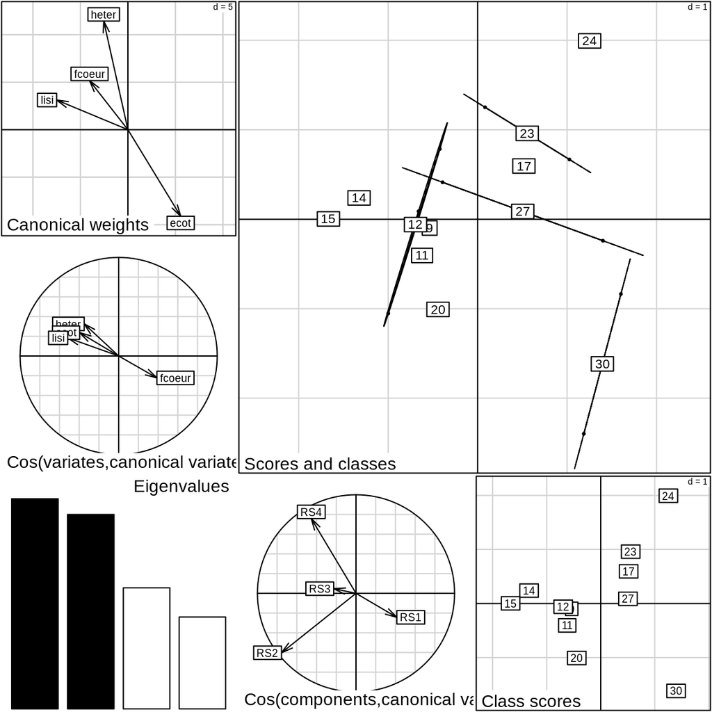

```r
########
afd.Frag.Taille = discrimin(acp.Frag,as.factor(especes$Taille)
                 , scannf = FALSE, nf = 2)

plot(afd.Frag.Taille)
```

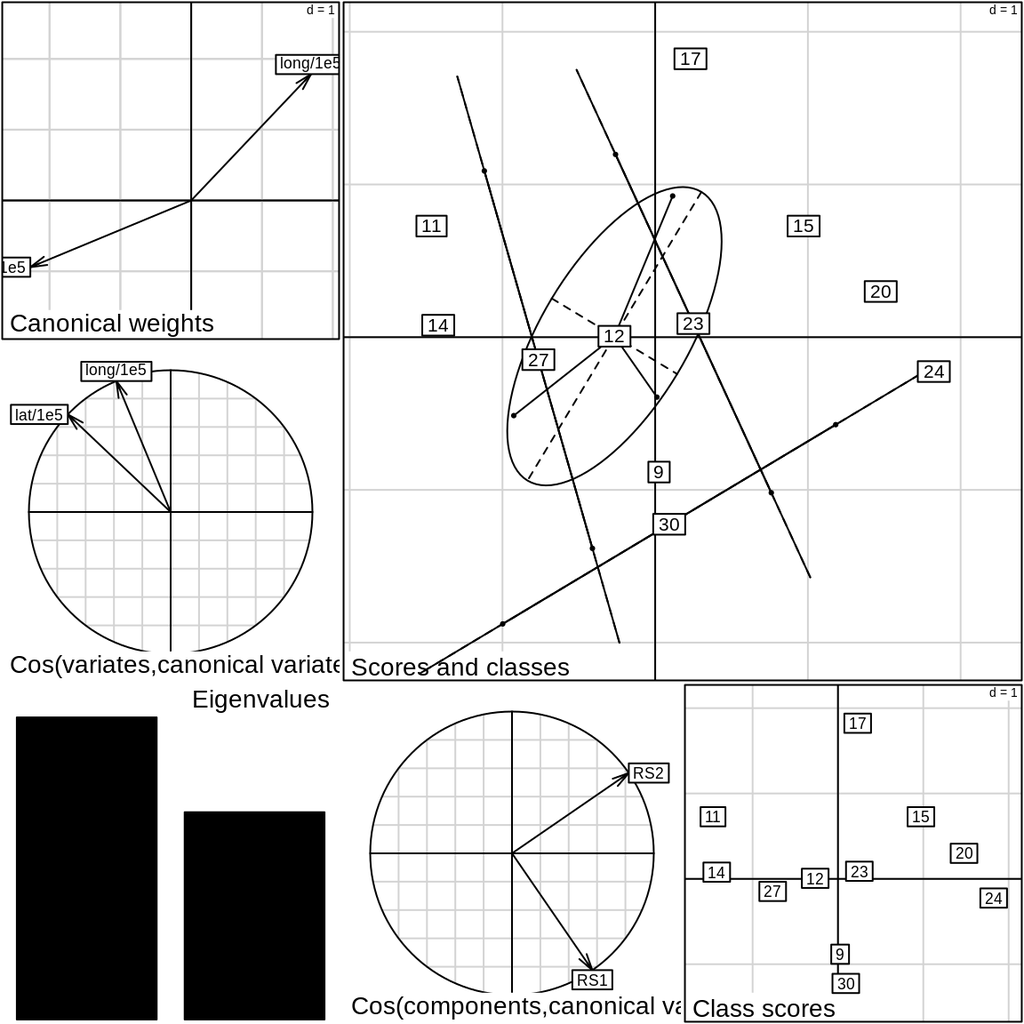

```r
########
afd.Mat.Taille = discrimin(acp.Topo,as.factor(especes$Taille)
                 , scannf = FALSE, nf = 2)

plot(afd.Ecoute.Taille)
```

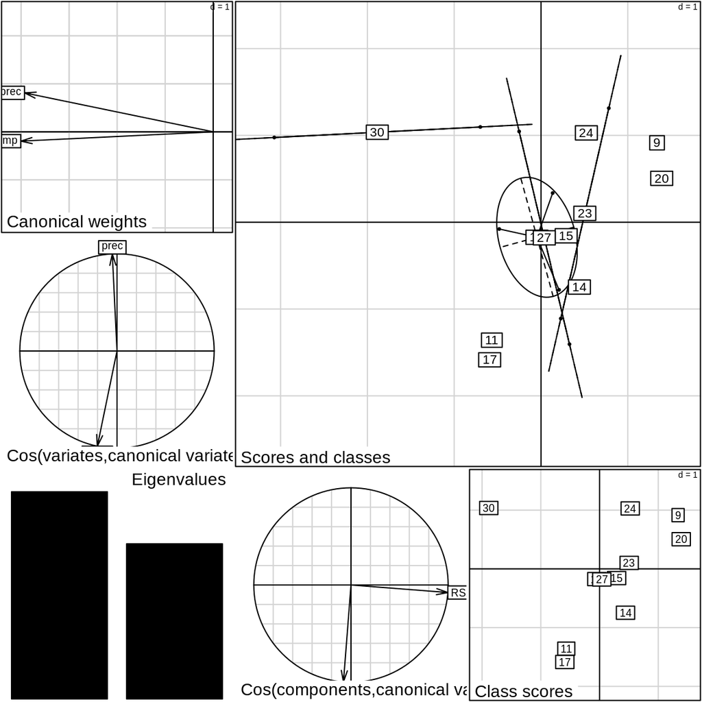

```r
########
afd.CondTopo.Taille = discrimin(acp.CondTopo,as.factor(especes$Taille)
                 , scannf = FALSE, nf = 2)

plot(afd.CondTopo.Taille)
```

#### ==> conclure :

Lieu d’écoute vs Taille des espèces :

> pas de création concluante de classe

12 et 23 peu expliquer par les 2 axes

20 et 24 ont les coordonnées similaires 9 et 30 // (// == pareil qu’au dessus) 11 et 14 // 11, 14 et 20,24 sont opposé

Ocuu vs Taille des espèces :

> toujours aucune classe concluante à part pour grouper le groupe 12 : Moqueur.grivotte

15 peu expliquer par le modèle arbu et hydro sont peu explicatif de notre modèle

l’espèce 23 a tendance a se retrouver en foret avec des grandes surfaces agricole

Frag vs Taille des espèces :

> rien de concluant

Les 4 variables sont explicative mais ont des vélocités colinéaires

l’espèce 30 est très ecot mais très peu heter et lisi

Topo vs Taille des espèces :

> pas de création concluante de classe

CondTopo vs Taille des espèces :

> same

Les 2 variables sont explicative mais ont des vélocités colinéaires

Global : on ne peut pas classer la taille des espèces en fonction de l’environnement

Cependant on voit que on peut séparer les tailles des espèces par l’environnement